# Data munging: manejo de datos con R, the tidyverse way

### pivot_longer() y pivot_wider()

#### funciones para pasar de wide a long (& viceversa)

Ya hemos dicho que los packages del tidyverse trabajan mejor con tidy data en **formato “long”**. ¿Qué hacemos si tenemos un dataframe en formato wide? Pues pasarlo a long. Afortunadamente tenemos un pkg que hace muy sencillo pasar los datos de wide a long (y viceversa): `tidyr`. Concretamente usaremos las funciones `pivot_longer()` y `pivot_wider()`[^1]

[Aquí](https://www.tidyverse.org/blog/2020/05/tidyr-1.1.0/) tienes el post oficial donde se anunciaba la llegada a CRAN de `tidyr 1.0.0` y [aquí](https://tidyr.tidyverse.org/articles/pivot.html) y [aquí](https://blog.methodsconsultants.com/posts/data-pivoting-with-tidyr/) un post detallado sobre ellas. La conclusión del autor del último de ellos es:

> The new tidyr functions have intuitive syntax, are easy to use, and are more flexibile than the prior functions. Several of the new arguments and features are extremely useful, and will save lots of time on common tasks.

En este [otro post](https://fromthebottomoftheheap.net/2019/10/25/pivoting-tidily/) tienes también una explicación detallada, de `pivot_*()` pero además incluye una serie de gifs que ejemplifican el paso de wide a long.

#### De wide a long format con `pivot_longer()`

La función `pivot_longer()` convierte dataframes de wide a long format

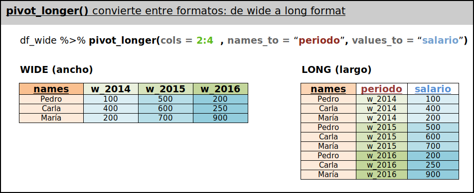

Hagámoslo:

```r
library(tidyr)
data_wide <- data_2   #- data_2 está en formato ancho (wide)

#- la función pivot_longer() transforma los datos de formato ancho(wide) a formato largo(long)
data_long <- data_wide %>% pivot_longer(cols = 2:4, names_to = "periodo")
```

Si quisiéramos arreglar los valores de los periodos:

```r
#(!!) stringr::str_replace encuentra el texto "W_" en la columna "periodo" y lo sustituye por ""
data_long <- data_long %>% mutate(periodo = str_replace(periodo, "W_", "" ))
```

#### De long a wide format con `pivot_wider()`

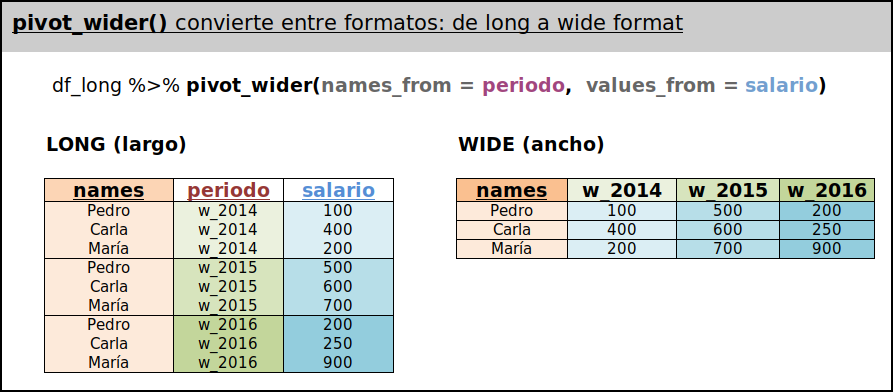

Hagámoslo:

```r
#- `pivot_longer()` convierte un df de long a wide
data_wide2 <- data_long %>% pivot_wider(names_from = periodo, values_from = value)
```

### separate() y unite()

#### funciones para separar y unir columnas

El pkg tidyr contiene otras 2 funciones: `separate()` y `unite()` que facilitan el separar y unir columnas. Veamos un ejemplo:

```r
df <- data.frame( names = c("Pedro_Navaja", "Bob_Dylan", "Cid_Campeador"),
                  year  = c(1978, 1941, 1048) )
df
```

| names | year |
| --- | --- |
| Pedro_Navaja | 1978 |
| Bob_Dylan | 1941 |
| Cid_Campeador | 1048 |

Separamos la primera columna:

```r
df_a <- df %>% separate(names, c("Nombre", "Apellido"), sep = "_")
df_a
```

| Nombre | Apellido | year |
| --- | --- | --- |
| Pedro | Navaja | 1978 |
| Bob | Dylan | 1941 |
| Cid | Campeador | 1048 |

Si queremos volver a unirlos, tendríamos que:

```r
df_b <- df_a %>% unite(Nombre_y_Apellido, Nombre:Apellido, sep = "&")
df_b
```

| Nombre_y_Apellido | year |
| --- | --- |
| Pedro&Navaja | 1978 |
| Bob&Dylan | 1941 |
| Cid&Campeador | 1048 |

#### mas funciones de tidyr

Además, recuerda que el paquete `tidyr` tiene muchas [más funciones](https://tidyr.tidyverse.org/reference/index.html) que nos facilitan conseguir que nuestros datos sean **tidy**.

# 3. DPLYR

En R hay varios enfoques para manipular datos en R, pero el más habitual, de hecho se ha convertido en el estándar, es utilizar el tidyverse, concretamente el paquete [`dplyr`](https://dplyr.tidyverse.org/).

`dplyr` es un paquete que permite manipular datos de forma intuitiva. Tiene 6-7 funciones o verbos principales. Cada uno de ellos hace “una sola cosa”, así que para realizar transformaciones complejas hay que ir concatenando instrucciones sencillas. Esto se hace con el **operador pipe** (`%>%`)

## dplyr basics

Tras mucho pensar como estructurábamos este apartado del tutorial, al final me decanté por utilizar los materiales del curso STAT 545. ¿que quien ha se encarga del curso? Pues Jenny Bryan (always rocks!!). Puedes encontrarlos [aquí](http://stat545.com/block009_dplyr-intro.html).

`dplyr` tiene muchas funciones, pero las principales son 6-7, luego las veremos. Con ellas se pueden resolver la mayoría de problemas asociados a la manipulación de datos.

Cada función (o verbo) hace una sola cosa, pero concatenándolas con `%>%` permiten resolver cuestiones complejas.

Todas las funciones tienen una estructura o comportamiento similar:

- el primer argumento siempre es un df. Esto es importante
- los siguientes argumentos describen que hacer con los datos
- el resultado es siempre un nuevo df. Esto es importante

Por ejemplo, `filter(df, X1 >= 10)` devuelve un df con las filas del df original que cumplen la condición de que la variable X1 es mayor o igual a 10

Podemos escribir la anterior instrucción de 3 formas. La más utilizada es la última:

```r
df_new <- filter(df, X1 >= 10)

df_new <- df %>% filter(. , X1 >= 10)

df_new <- df %>% filter(X1 >= 10)
```

# 4. Principales funciones de dplyr

Hay 6-7 principales.

- `filter()` : permite seleccionar filas (que cumplen una o varias condiciones)
- `arrange()`: reordena las filas (`arrange()`).
- `rename()` : cambia los nombres de las columnas (variables)
- `select()` : selecciona columnas (variables)
- `mutate()` : crea nuevas variables
- `summarise()` : resume (colapsa) unos cuantos valores a uno sólo. Por ejemplo, calcula la media, moda, etc… de un conjunto de valores

Hay una séptima:

- `group_by()` : permite agrupar filas en función de una o varias condiciones

Y después de `dplyr 1.0.0`, en mayo de 2020, añado 2 más:

- `across()` y `where()`. Estas funciones son un poco diferentes, solo se usan en combinación de otro función/verbo. Son 2 funciones que en la jerga del tidyverse no son verbos sino adverbios. Lo vemos

Veámoslas una a una. Veremos sólo algunos ejemplos. Ya iremos practicando

## `filter()`

Esta función (o verbo) se utiliza para **seleccionar filas** de un dataframe (df). Se seleccionan las filas que cumplen una determinada condición o criterio lógico. Por ejemplo:

```r
#- vamos a trabajar con los datos del [pkg gapminder](https://github.com/jennybc/gapminder)
gapminder <- gapminder::gapminder
```

Seleccionamos las filas que cumplen determinados criterios:

```r
#- Observaciones de España (country == "Spain")
aa <- gapminder %>% filter(country == "Spain")

#- filas con valores de "lifeExp" < 29
aa <- gapminder %>% filter(lifeExp < 29)

#- filas con valores de "lifeExp" entre [29, 32]
aa <- gapminder %>% filter(lifeExp >=  29 , lifeExp <= 32)
aa <- gapminder %>% filter(lifeExp >=  29 &  lifeExp <= 32)
aa <- gapminder %>% filter(between(lifeExp, 29, 32))

#- observaciones de paises de África con lifeExp > 32
aa <- gapminder %>% filter(lifeExp > 72 &  continent == "Africa")

#- observaciones de países de África o Asia con lifeExp > 32
aa <- gapminder %>% filter(lifeExp > 72 &  continent %in% c("Africa", "Asia") )
aa <- gapminder %>% filter(lifeExp > 72 & (continent == "Africa" | continent == "Asia") )
```

La función `filter()` tiene muchas más posibilidades. Ya las iremos viendo. PERO si quieres ver un resumen de las posibilidades del paquete dplyr mira su [CHEAT SHEET](https://www.rstudio.com/resources/cheatsheets/). [^2]. La [versión antigua](https://www.rstudio.com/wp-content/uploads/2015/02/data-wrangling-cheatsheet.pdf) de la Cheat sheet contiene también las funciones de `tidyr`.

#### `slice()` también es muy útil para seleccionar filas

- `slice()`: filtra filas por su posición (física en el df)

Como dijimos, `slice()` sirve para seleccionar filas por posición:

```r
#- selecciona las observaciones de la décima a la quinceava
aa <- gapminder %>% slice(c(10:15))

#- selecciona las observaciones de la 12 a 13 Y de la 44 a 46, Y las 4 últimas
aa <- gapminder %>% slice( c(12:14, 44:46, n()-4:n()) ) #- AQUI hay un error, tenéis que arreglarlo.

#- Pista: igual os ayuda crear una columna con el índice de rows y repetir el cálculo
aa <- gapminder %>% mutate(index = 1:n())
aa <- gapminder %>% slice( c(12:14, 44:46, n()-4:n()) )
```

#### variantes de `slice()`

Hay varias variantes de `slice()`. Concretamente `slice_max()` `slice_min()`, `slice_smpl()`, `slice_head()` `slice_tail()`. Veremos algún ejemplo con las 3 primeras.

Si queremos seleccionar las filas que tienen el valor máximo (o mínimo) de una determinada variable, podemos usar `slice_max()` y `slice_min()`

```r
#- selecciona las 3 filas con mayor valor de lifeExp
aa <- gapminder %>% slice_max(lifeExp, n = 3)
#- selecciona las 4 filas con MENOR valor de pop
aa <- gapminder %>% slice_min(pop, n = 4)
```

Para ver la potencialidad de una función tienes que ver su ayuda interna (presionando F1 o con `help()`). Por ejemplo `slice_min()` tiene otro argumento (`prop`) que nos permite calcular, por ejemplo, el 10% de observaciones/países con menor esperanza de vida.

```r
#- observaciones en el primer decil en cuanto a esperanza de vida, 10% con menor esperanza de vida
aa <- gapminder %>% slice_min(lifeExp, prop = 0.1)
#- 1% de observaciones con mayor población. Imagino que estarán China e India
aa <- gapminder %>% slice_max(pop, prop = 0.01)
```

A veces se necesita obtener una muestra aleatoria de los datos. La función `slice_sample()` está diseñada para ayudarnos en esta tarea:

```r
#- selecciona (aleatoriamente) 100 filas de los datos
aa <- gapminder %>% slice_sample(n = 100)
#- selecciona (aleatoriamente) un 5% de los datos
aa <- gapminder %>% slice_sample(prop = 0.05)
```

## `arrange()`

Esta función (o verbo) se utiliza para **reordenar las filas** de un dataframe (df).

```r
#- ordena las filas de MENOR a mayor según los valores de la v. lifeExp
aa <- gapminder %>% arrange(lifeExp)

#- ordena las filas de MAYOR a menor según los valores de la v. lifeExp
aa <- gapminder %>% arrange(desc(lifeExp))

#- ordenada las filas de MENOR a mayor según los valores de la v. lifeExp.
#- Si hay empates se resuelve con la variable "pop"
aa <- gapminder %>% arrange(lifeExp, pop)
```

## `rename()`

Esta función permite cambiar los nombres de las columnas

```r
#- cambia los nombres de lifeExp y gdpPercap a life_exp y gdp_percap
gapminder %>% rename(life_exp = lifeExp,  gdp_percap = gdpPercap)

#-(!!) la función names() de R-base es muy útil. Tb setNames() y set_names()
aa <- gapminder
names(aa) <- names(aa) %>% toupper
names(aa) <- names(aa) %>% tolower
names(aa) <- c("var_01", "var_02", "var_03", "var_04", "var_05" , "var_06")
names(aa) <- paste0("Var_", 1:6)
names(aa) <- paste0("Lag_", formatC(1:6, width = 2, flag = "0"))
```

#### rename_with() , una variante de rename()

Si tienes que hacer transformaciones más complejas, que requieran el uso de funciones o pautas, de los nombres de las variables puedes usar `rename_with()`

```r
aa <- gapminder
rename_with(aa, toupper)
rename_with(aa, toupper, starts_with("Life") | contains("countr"))
rename_with(aa, ~ str_replace(.x, "e", "Ö"))  #- (!!!!)
```

La función `rename()` es útil pero, enseguida veremos que la siguiente función, `select()`, también permite renombrar las columnas, e incluso reordenar la posición de estas.

## `select()`

Esta función (o verbo) sirve para **seleccionar columnas** de un df.

#### seleccionar variables por nombre

Seleccionamos las variables “year” y “lifeExp”:

```r
#- Se lee como: “Take el df gapminder, then select the variables year and lifeExp”
aa <- gapminder %>% select(year, lifeExp)
aa <- gapminder %>% select(c(year, lifeExp))
```

#### quitar variables

Para eliminar una variable hay varias formas:

```r
aa <- gapminder %>% select(-year)   #- la forma mas habitual

#- estas dos formas son mucho menos habituales
aa <- gapminder %>% select(!year)
aa <- gapminder %>% mutate(year = NULL)   #- aún no hemos visto mutate()
```

Para eliminar varias variables:

```r
#- quitamos las variables: year y lifeExp
aa <- gapminder %>% select(-c(year, lifeExp))
```

#### seleccionar por posición

Seleccionamos las variables del df gapminder siguientes: de la primera a la tercera y también la quinta (mejor seleccionarlas por nombre!!)

```r
#- seleccionamos las variables {1, 2, 3 y 5}
aa <- gapminder %>% select(1:3, 5)
```

#### quitar variables por posición

Seleccionamos todas las variables del df gapminder **excepto** las siguientes: de la primera a la tercer y la quinta (mejor seleccionarlas por nombre)

```r
#- quitamos las variables {1, 2, 3 y 5}
aa <- gapminder %>% select(- c(1:3, 5))
```

#### `select()` con la función auxiliar `where()`

En el data.frame `gapminder` las 2 primeras variables (country y continent) son factores y las 4 siguientes son variable numéricas.

```r
print(gapminder, n = 3)
```

```
#> # A tibble: 1,704 x 6
#>   country     continent  year lifeExp      pop gdpPercap
#>   <fct>       <fct>     <int>   <dbl>    <int>     <dbl>
#> 1 Afghanistan Asia       1952    28.8  8425333      779.
#> 2 Afghanistan Asia       1957    30.3  9240934      821.
#> 3 Afghanistan Asia       1962    32.0 10267083      853.
#> # … with 1,701 more rows
```

Imagina que queremos seleccionar sólo las variables que son numéricas. Podemos hacerlo por nombre o por posición pero mejor con `select()` y la función auxiliar `where()`[^3].

```r
aa <- gapminder %>% select(is.numeric)        #- funciona, pero ...
aa <- gapminder %>% select(where(is.numeric)) #- es "preferible" esta segunda expresión
```

`select()` y `where()` son dos funciones, sí, pero en la jerga del tidyverse, `select()` es un verbo y `where()` es un adverbio, cualifica/cambia lo que hace `select()`.

Si quisiéramos seleccionar las variables que no son numéricas haríamos:

```r
aa <- gapminder %>% select(!is.numeric)
aa <- gapminder %>% select(!where(is.numeric))  #- es preferible esta segunda expresión
```

La función `select()` tiene muchas más posibilidades. ya las iremos viendo. PERO si quieres ver un resumen de las posibilidades del pkg dplyr mira su [CHEAT SHEET](https://www.rstudio.com/resources/cheatsheets/).

#### renombrando y reordenando columnas con `select()`

Lo que sí vamos a ver son 2 posibilidades de `select()` que son muy útiles. Con `select()` podemos: **renombrar** y **reordenar** las columnas:

```r
#- dejamos en aa solamente a las columnas "year" y "pop"; ADEMÁS, ahora, "pop" irá antes que "year"
aa <- gapminder %>% select(pop, year)
```

```r
#- dejamos en aa solamente a las columnas "year" y "pop" y les cambiamos el nombre
aa <- gapminder %>% select(poblacion = pop, año = year)
```

Imagina que quieres que la última columna pase a ser la primera (manías!!). Podemos hacerlo con select y `everything()`. everything es una **función auxiliar**:

```r
#- "gdpPercap" que es la última columna pasa a ser la primera
aa <- gapminder %>% select(gdpPercap, everything())

#(!!) otras 3 formas de hacer lo mismo: que la última columna pase a ser la primera
aa <- gapminder %>% select(ncol(df), everything())
aa <- gapminder %>% select(length(df), everything())
aa <- gapminder %>% select(last_col(), everything())  #- usamos the selection helper last_col()
```

En la última instrucción hemos usado dos funciones auxiliares de select(), dos “helper functions”. La lista completa de funciones auxiliares para select() puedes verla [aquí](https://tidyselect.r-lib.org/reference/select_helpers.html).

#### `relocate()`

Desde dplyr 1.0.0, tenemos otra función para reordenar las variables de un data.frame: `relocate()`. Veámosla en acción:

```r
aa <- gapminder %>% dplyr::relocate(country, .after = lifeExp)
aa <- gapminder %>% dplyr::relocate(country, .before = lifeExp)
```

Las opciones `.after` y `.before` también están disponibles en `mutate()`, la siguiente función que presentaremos.

## `mutate()`

Esta función (o verbo) sirve para **crear nuevas variables** (columnas). Lógicamente, es muy útil en análisis de datos.

Creamos la variable: `GDP = pop*gdpperCap`

```r
#- Creamos la variable: GDP = pop*gdpperCap
aa <- gapminder %>% mutate(GDP = pop*gdpPercap)
```

Por defecto, la nueva variable creada se situará al final del data frame, a no ser que usemos los argumentos `.after` y `.before`

```r
aa <- gapminder %>% mutate(GDP = pop*gdpPercap, .after = country)
aa <- gapminder %>% mutate(GDP = pop*gdpPercap, .before = country)
```

`mutate()` también tiene un argumento(`.keep`) para controlar que variables permanecen en el data frame. Por ejemplo, en el chunk de abajo dejaremos solo las variables usadas.

```r
aa <- gapminder %>% mutate(GDP = pop*gdpPercap, .keep = "used")
```

## `summarise()`

Esta función (o verbo) sirve para **RESUMIR** (o “colapsar filas”). Coge una variable o grupo de valores como input y devuelve un solo valor; por ejemplo, haya la media aritmética (o el mínimo, o el máximo …) de una columna/variable.

Obtengamos determinados estadísticos de **una variable**. Para esto no nos hace falta `dplyr` pero conviene ir habituándose a su sintaxis.

```r
#- retornará un único valor: la media global de la v. "lifeExp"
aa <- gapminder %>% summarise(media = mean(lifeExp))

#- retornará un único valor: el número de filas
aa <- gapminder %>% summarise(NN = n())
aa <- gapminder %>% count()                #- más adelante veremos la utilidad de count()


#- retornará un único valor: la desviación típica de la v. "lifeExp"
aa <- gapminder %>% summarise(desviacion_tipica = sd(lifeExp))

#- retornará un único valor: el máximo de la variable "pop"
aa <- gapminder %>% summarise(max(pop))

#- retornará 2 valores: la media y sd de la v. "lifeExp"
aa <- gapminder %>% summarise(mean(lifeExp), sd(lifeExp))

#- retornará 2 valores: las medias de "lifeExp" y "gdpPercap"
aa <- gapminder %>% summarise(mean(lifeExp), mean(gdpPercap))
```

#### `across()` y `where()`

Antes de pasar a ver `group_by()`, vamos a utilizar las 2 nuevas funciones `across()` y `where()`.

Muchas veces en un trabajo se han de calcular estadísticos de **todas las variables** del df. Esto se hace con `summarise()`, PERO utilizando también una función de ayuda (helper function): `across()`[^4]. A veces también hay que usar otra helper function: `where()`.

La sintaxis de `across()` es:

`across(.cols = everything(), .fns = NULL, ..., .names = NULL)`; es decir,

`across("columnas seleccionadas", "funciones o cálculos a realizar", "si quieres controlar los nombres"))`.

Si al seleccionar las columnas utilizas algún criterio lógico, como por ejemplo `is.numeric()`, entonces la sintaxis de `across()` es un poco diferente; concretamente será:

`across( where("columnas seleccionadas"), "funciones o cálculos a realizar", "si quieres controlar los nombres"))`

Los ejemplos ayudan a entenderlo:

```r
#- media de cada una de las 6 variables. Devuelve 2 warnings porque las 2 primeras son textuales. No se puede calcular la media de continent y country
gapminder %>% summarise(across(everything(), mean) )

#- calculamos la media de tercera a la sexta variable
gapminder %>% summarise(across(3:6, mean) )
```

Lo que os decía de seleccionar columnas con un criterio lógico y usar `where()`

```r
gapminder %>% summarise(across(where(is.numeric), mean))

#- con los nombres de los argumentos (más largo pero conviene verlo de vez en cuando)
gapminder %>% summarise(across(.cols = where(is.numeric), .fns = mean))
```

Vamos a calcular cosas un poco más complejas. Imagina que no sólo quieres calcular la media sino que también quieres calcular la desviación típica. Seguiremos usando `summarise()` y `across()`. Lo único nuevo es que como vamos a aplicar dos funciones (`mean()` y `sd()`) las tenemos que poner dentro de `list()`. Tiene sentido, es una lista de funciones a aplicar a las columnas que seleccionemos con `across()`

```r
#- calculamos la media y desviación típica de las columnas 3 a 6.
gapminder %>% summarise(across(3:6, list(media = mean, desv = sd)))

#- lo mismo, pero explicitando los nombres de los argumentos
gapminder %>% summarise(across(.cols = 3:6, .fns = list(media = mean, desv = sd) ))

#- lo mismo otra vez, pero eligiendo el nombre de las variables que se van aa crear con .names
gapminder %>% summarise(across(3:6, list(media = mean, desv = sd), .names = "{fn}_{col}"))
```

(!!!)Imagina que quisiéramos presentar en una tabla los anteriores resultados; tendríamos que usar `tidyr::pivot_longer()`. Lo voy a hacer por trozos. Nos va a costar un poco:

```r
aa <- gapminder %>% summarise(across(3:6, list(media = mean, desv = sd), .names = "{fn}_{col}"))

aa1 <- aa %>% pivot_longer(1:8, names_to = "names", values_to = "values")
aa2 <- aa1 %>% separate(names, into = c("operacion", "variable"), sep =  "_") %>%
               select(variable, everything())
aa3 <- aa2 %>% pivot_wider(1:3, names_from = operacion, values_from = values)
```

Lo practicaremos, y veremos métodos más sencillos para hacer tablas con estadísticos descriptivos, pero eso será en el tutorial dedicado a tablas; pero no os olvidéis de `across()` que luego tenemos que volver a ella.

## `group_by()`

Con esta función ya empezaremos a ver la potencia de dplyr. En análisis de datos muchas operaciones (media etc..) queremos calcularlas para distintos grupos (hombre, mujer …). `group_by()` permite hacerlo.

`group_by()`coge un df y lo convierte en un **“df agrupado”**. En ese nuevo “df agrupado”, las operaciones que hagamos con `summarise()` se harán por separado para cada uno de los grupos que hayamos definido. Ahora lo vemos.

Si, por ejemplo, agrupamos un df por países, al ejecutar `summarise()`, nos retornará una fila con el resultado para cada país. En realidad, podemos pensar que `group_by()` no hace “nada”, que en realidad solo cambia lo que hacen las otras funciones: ahora los cálculos se harán para cada uno de los grupos que define `group_by()`

Como dice Jenny: Let’s start with simple counting. ¿Cuantas observaciones(rows) tenemos por continente?

```r
#- cogemos df y lo (des)agrupamos por grupos definidos por la variable "continent"; osea, habrá 5 grupos
#- después con summarise() calcularemos el nº de observaciones en cada continente o grupo; es decir, nos retornará un df con una fila por cada continente
aa <- gapminder %>% group_by(continent) %>% summarise(NN = n())
aa
```

| continent | NN |
| --- | --- |
| Africa | 624 |
| Americas | 300 |
| Asia | 396 |
| Europe | 360 |
| Oceania | 24 |

Esto tan sencillo también se puede hacer con `count()`

```r
aa <- gapminder %>% group_by(continent) %>% count()
aa <- gapminder %>% group_by(continent) %>% count(name = "NN")
aa
```

¿Y cuantos países hay en la base de datos? Para este tipo de cosas, se pueden usar funciones de R-base, pero dplyr tiene muchas funciones auxiliares.

```r
#- cogemos df y lo agrupamos por "continent",
#- después calculamos 2 cosas: el número de observaciones o rows
#- y el número de países en cada continente (NN_countries)
aa <- gapminder %>% group_by(continent) %>%
          summarize(NN = n(),
                    NN_countries = n_distinct(country))
aa
```

| continent | NN | NN_countries |
| --- | --- | --- |
| Africa | 624 | 52 |
| Americas | 300 | 25 |
| Asia | 396 | 33 |
| Europe | 360 | 30 |
| Oceania | 24 | 2 |

Calculemos la esperanza de vida media por continente

```r
#- cogemos df y lo agrupamos por "continent", después calculamos la media de "lifeExp"
aa <- gapminder %>% group_by(continent) %>%
                    summarize(mean(lifeExp))
aa
```

| continent | mean(lifeExp) |
| --- | --- |
| Africa | 48.86533 |
| Americas | 64.65874 |
| Asia | 60.06490 |
| Europe | 71.90369 |
| Oceania | 74.32621 |

Guau! Hay que irse a vivir a Oceanía!!

Calculemos la esperanza de vida media por continente en el primer periodo (1952)

```r
#- cogemos df y filtramos para quedarnos con las observaciones de 1952
#- después lo agrupamos por "continent",
#- después calculamos la media de "lifeExp"
gapminder %>% filter(year == "1952") %>%
              group_by(continent) %>%
              summarize(mean(lifeExp))
```

| continent | mean(lifeExp) |
| --- | --- |
| Africa | 39.13550 |
| Americas | 53.27984 |
| Asia | 46.31439 |
| Europe | 64.40850 |
| Oceania | 69.25500 |

Habría sido mejor en lugar de poner `filter(year == "1952")` haber puesto `filter(year == min(year))`

Guau! Habría que haber vivido en Oceanía (en 1952)!!

Se pueden calcular varios estadísticos a la vez

```r
#- cogemos df y filtramos (cogemos) las observaciones de 1952 y 2007
#- agrupamos por "continent",
#- después calculamos la media de "lifeExp" y de "gdpPercap"
gapminder %>% filter(year %in% c(1952, 2007)) %>%
             group_by(continent, year) %>%
             summarize(mean(lifeExp), mean(gdpPercap))
```

Vamos a hacer cálculos cada vez más complejos:

```r
#- cogemos df y lo agrupamos por "continent" y "year",
#- después calculamos la media de "lifeExp" y de "gdpPercap"
gapminder %>% filter(year %in% c(1952, 2007)) %>%
              group_by(continent, year) %>%
              #- después calculamos la media de "lifeExp"
              summarise(media = mean(lifeExp))
```

```r
#- Voy a crear un nuevo df: "gapminder_gr" o "gapminder agrupado"
gapminder_gr <- gapminder %>% filter(year %in% c(1952, 2007)) %>%
                 group_by(continent, year)
#- y sobre "gapminder_gr" iremos haciendo cálculos

#- si queremos calcular la media de varias variables tenemos que usar across()
gapminder_gr %>% summarise(across(c(lifeExp, gdpPercap), mean))

#- si queremos calcular la media de todas las variables numéricas tenemos que usar across() y where()
gapminder_gr %>% summarise(across(where(is.numeric), mean))

#- si queremos calcular la media y la mediana, hay que usar list()
gapminder_gr %>% summarise(across(c(lifeExp, gdpPercap),
                            list (media = mean, mediana = median) ))

#- si ponemos los nombres de los argumentos quedaría como
gapminder_gr %>% summarise(across(.cols = c(lifeExp, gdpPercap),
                                  .fns = list (media = mean, mediana = median)))

#- además, podemos controlar el nombre de las variables creadas con el argumento .names
gapminder_gr %>% summarise(across(c(lifeExp, gdpPercap),
                        list (media = mean, mediana = median),
                        .names = "{fn}_{col}"))
```

#### Preguntas de verdad

Bueno, pues ya conocéis lo principal, lo básico y más importante de `dplyr`, solo queda ir cogiendo práctica y confianza, así que para ello toca hacer una serie de **preguntas de verdad!!**. Por ejemplo:

1. ¿en que continente ha aumentado más la esperanza de vida en el periodo 1952-2007?

```r
#- cogemos df y lo agrupamos por "continent", después calculamos la media de "lifeExp"
gapminder %>%
  filter(year %in% c(1952, 2007)) %>%
  group_by(continent, year) %>%
  summarize(media = mean(lifeExp)) %>% ungroup()
```

| continent | year | media |
| --- | --- | --- |
| Africa | 1952 | 39.13550 |
| Africa | 2007 | 54.80604 |
| Americas | 1952 | 53.27984 |
| Americas | 2007 | 73.60812 |
| Asia | 1952 | 46.31439 |
| Asia | 2007 | 70.72848 |
| Europe | 1952 | 64.40850 |
| Europe | 2007 | 77.64860 |
| Oceania | 1952 | 69.25500 |
| Oceania | 2007 | 80.71950 |

Casi, pero no!! Sólo hemos conseguido ver la esperanza de vida por continente en 1952 y 2007.En realidad esto ya lo hicimos antes. Falta restar.

Quizás podríamos calcular el máximo, el mínimo y restarlos. No, porque supondríamos que “lifeExp” siempre aumenta. Vamos que el tiempo apremia:

```r
#- primer intento: se puede hacer de una vez, pero vamos a partir el código en 2 trozos
aa <- gapminder %>% filter(year %in% c(1952, 2007)) %>%
  group_by(continent, year) %>%
  summarize(media = mean(lifeExp)) %>% ungroup()

aa1 <- aa %>% group_by(continent) %>%
  summarise(min_l = min(media), max_l = max(media)) %>%
  mutate(dif = max_l-min_l) %>%
  arrange(desc(dif))

aa1
```

| continent | min_l | max_l | dif |
| --- | --- | --- | --- |
| Asia | 46.31439 | 70.72848 | 24.41409 |
| Americas | 53.27984 | 73.60812 | 20.32828 |
| Africa | 39.13550 | 54.80604 | 15.67054 |
| Europe | 64.40850 | 77.64860 | 13.24010 |
| Oceania | 69.25500 | 80.71950 | 11.46450 |

Asia son los ganadores. En promedio, en Asía se mejoró la esperanza de vida en 24.4 años entre 1952 y 2007.

Lo de restar el máximo y el mínimo ha funcionado, PERO podría no haberlo hecho si hubiese habido algún continente en el que en la esperanza de vida, en lugar de haber aumentado, hubiese bajado. Entonces, ¿cómo lo hacemos?

```r
#- segundo intento: se puede hacer de una vez, pero vamos a partir el código en 2 trozos
aa <- gapminder %>% filter(year %in% c(1952, 2007)) %>%
         group_by(continent, year) %>%
         summarize(media = mean(lifeExp)) %>% ungroup()

#- usamos lag()
aa1 <- aa %>% group_by(continent) %>%
              arrange(year) %>%
              mutate(variac_l = media - lag(media))

#- mostramos los resultados
aa1 %>% filter(year == 2007) %>% arrange(desc(variac_l))
```

| continent | year | media | variac_l |
| --- | --- | --- | --- |
| Asia | 2007 | 70.72848 | 24.41409 |
| Americas | 2007 | 73.60812 | 20.32828 |
| Africa | 2007 | 54.80604 | 15.67054 |
| Europe | 2007 | 77.64860 | 13.24010 |
| Oceania | 2007 | 80.71950 | 11.46450 |

Sí, Asia es la ganadora. En promedio, en Asía se mejoró la esperanza de vida en 24 años entre 1952 y 2007.

Otra forma de obtener el mismo resultado:

```r
#- esta parte es común
aa <- gapminder %>%
  filter(year %in% c(1952, 2007)) %>%
  group_by(continent, year) %>%
  summarize(media = mean(lifeExp)) %>% ungroup()

#- pero ahora usamos pivot_wider()
aa %>% pivot_wider(names_from = year, values_from = media) %>%
     mutate(dif_l = `2007` - `1952`) %>%
     arrange(desc(dif_l))
```

| continent | 1952 | 2007 | dif_l |
| --- | --- | --- | --- |
| Asia | 46.31439 | 70.72848 | 24.41409 |
| Americas | 53.27984 | 73.60812 | 20.32828 |
| Africa | 39.13550 | 54.80604 | 15.67054 |
| Europe | 64.40850 | 77.64860 | 13.24010 |
| Oceania | 69.25500 | 80.71950 | 11.46450 |

El chunk de abajo, ¿qué hace? ¿qué se está calculando?:

```r
aa <- gapminder %>%
  group_by(continent, year) %>%
  select(continent, year, lifeExp) %>%
  summarise(mean_life = mean(lifeExp)) %>%
  arrange(year) %>%
  mutate(incre_mean_life_0 = mean_life - first(mean_life)) %>%
  mutate(incre_mean_life_t = mean_life - lag(mean_life)) %>%
  arrange(continent)

#- por ejemplo veamos el resultado para Europe
aa %>% filter(continent == "Europe")
```

| continent | year | mean_life | incre_mean_life_0 | incre_mean_life_t |
| --- | --- | --- | --- | --- |
| Europe | 1952 | 64.40850 | 0.000000 | NA |
| Europe | 1957 | 66.70307 | 2.294567 | 2.2945667 |
| Europe | 1962 | 68.53923 | 4.130733 | 1.8361667 |
| Europe | 1967 | 69.73760 | 5.329100 | 1.1983667 |
| Europe | 1972 | 70.77503 | 6.366533 | 1.0374333 |
| Europe | 1977 | 71.93777 | 7.529267 | 1.1627333 |
| Europe | 1982 | 72.80640 | 8.397900 | 0.8686333 |
| Europe | 1987 | 73.64217 | 9.233667 | 0.8357667 |
| Europe | 1992 | 74.44010 | 10.031600 | 0.7979333 |
| Europe | 1997 | 75.50517 | 11.096667 | 1.0650667 |
| Europe | 2002 | 76.70060 | 12.292100 | 1.1954333 |
| Europe | 2007 | 77.64860 | 13.240100 | 0.9480000 |

Sed conscientes de que la soluciones a una pregunta no sale a la primera, a veces hay que calentarse el cap:

> Break the code into pieces, starting at the top, and inspect the intermediate results. That’s certainly how I was able to write such a thing. These commands do not leap fully formed out of anyone’s forehead – they are built up gradually, with lots of errors and refinements along the way. Is the statement above really hard for you to read? If yes, then by all means break it into pieces and make some intermediate objects. Your code should be easy to write and read when you’re done. —- Jenny Bryan

Otras cuestiones que podemos resolver con dplyr sobre la esperanza de vida:

- ¿Cómo ha evolucionado la esperanza de vida en Spain lustro a lustro?

```r
#- variación de lifeExp en Spain año a año (bueno lustro a lustro)
aa <- gapminder %>%
  group_by(country) %>%
  select(country, year, lifeExp) %>%
  mutate(lifeExp_gain_cada_lustro = lifeExp - lag(lifeExp)) %>%
  filter(country == "Spain" )
aa
```

| country | year | lifeExp | lifeExp_gain_cada_lustro |
| --- | --- | --- | --- |
| Spain | 1952 | 64.940 | NA |
| Spain | 1957 | 66.660 | 1.720 |
| Spain | 1962 | 69.690 | 3.030 |
| Spain | 1967 | 71.440 | 1.750 |
| Spain | 1972 | 73.060 | 1.620 |
| Spain | 1977 | 74.390 | 1.330 |
| Spain | 1982 | 76.300 | 1.910 |
| Spain | 1987 | 76.900 | 0.600 |
| Spain | 1992 | 77.570 | 0.670 |
| Spain | 1997 | 78.770 | 1.200 |
| Spain | 2002 | 79.780 | 1.010 |
| Spain | 2007 | 80.941 | 1.161 |

- ¿Y la variación acumulada? Fácil!! Sólo tendríamos que sumar o acumular la variable “lifeExp_gain_cada_lustro” que hemos generado anteriormente, así que sólo habría que añadir una linea a nuestro código:

```r
#- ganancia acumulada
aa <- gapminder %>%
  group_by(country) %>%
  select(country, year, lifeExp) %>%
  mutate(lifeExp_gain_cada_lustro = lifeExp - lag(lifeExp)) %>%
  #--- 2 filas nuevas: ifelse()  y cumsum()
  mutate(lifeExp_gain_cada_lustro2 = ifelse(is.na(lifeExp_gain_cada_lustro), 0, lifeExp_gain_cada_lustro)) %>%
  mutate(lifeExp_gain_acumulado = cumsum(lifeExp_gain_cada_lustro2)) %>%
  filter(country == "Spain")
aa
```

| country | year | lifeExp | lifeExp_gain_cada_lustro | lifeExp_gain_cada_lustro2 | lifeExp_gain_acumulado |
| --- | --- | --- | --- | --- | --- |
| Spain | 1952 | 64.940 | NA | 0.000 | 0.000 |
| Spain | 1957 | 66.660 | 1.720 | 1.720 | 1.720 |
| Spain | 1962 | 69.690 | 3.030 | 3.030 | 4.750 |
| Spain | 1967 | 71.440 | 1.750 | 1.750 | 6.500 |
| Spain | 1972 | 73.060 | 1.620 | 1.620 | 8.120 |
| Spain | 1977 | 74.390 | 1.330 | 1.330 | 9.450 |
| Spain | 1982 | 76.300 | 1.910 | 1.910 | 11.360 |
| Spain | 1987 | 76.900 | 0.600 | 0.600 | 11.960 |
| Spain | 1992 | 77.570 | 0.670 | 0.670 | 12.630 |
| Spain | 1997 | 78.770 | 1.200 | 1.200 | 13.830 |
| Spain | 2002 | 79.780 | 1.010 | 1.010 | 14.840 |
| Spain | 2007 | 80.941 | 1.161 | 1.161 | 16.001 |

Al final para hacerlo (como había pensado) me han hecho falta 2 lineas, porque la primera observación de “lifeExp_gain_cada_lustro” es un NA y eso hacía que la función `cumsum()` no funcionase.

- Otra forma de hacer lo mismo sería (se me ha ocurrido después). Además es más fácil

```r
#- ganancia acumulada (otra forma de hacer lo mismo)
aa <- gapminder %>%
  group_by(country) %>%
  select(country, year, lifeExp) %>%
  mutate(lifeExp_gain_acumulada = lifeExp - lifeExp[1])  %>%
  filter(country == "Spain")
```

- Obtener, para cada periodo, los (3) países de Asia con MAYOR lifeExp. Usaremos una variante de `slice()`, concrétamente `slice_max()`

```r
aa <- gapminder %>%
  filter(continent == "Asia") %>%
  select(year, country, lifeExp) %>%
  group_by(year) %>%
  slice_max(n = 3, lifeExp) %>%
  arrange(year)
```

Para obtener los 4 países con **MENOR** “lifeExp” sólo tendríamos que sustituir la quinta linea por `slice_min(n = 4, lifeExp)`

- Obtener, para cada periodo, los países de Asia con mayor y menor lifeExp.

```r
#- Obtener, para cada periodo, los países de Asia con mayor y menor lifeExp.
aa <- gapminder %>%
  filter(continent == "Asia") %>%
  select(year, continent, country, lifeExp) %>%
  group_by(year) %>%
  filter(min_rank(desc(lifeExp)) < 2 | min_rank(lifeExp) < 2) %>%
  arrange(year)
```

Las 2 últimas funciones que hemos usado: `slice_min()` y `min_rank()` son funciones de dplyr pero no son son funciones principales, en cierta forma son auxiliares.

Podéis ver las funciones auxiliares que tiene dplyr en la segunda página de [CHEAT SHEET](https://www.rstudio.com/resources/cheatsheets/). también se pueden usar las funciones de R-base o de otros packages. Aquí tenéis algunas posibilidades sacadas de un [tutorial de Hadley](https://www.dropbox.com/sh/i8qnluwmuieicxc/AAAgt9tIKoIm7WZKIyK25lh6a?preview=dplyr-tutorial.pdf)

```r
Types of summary functions:
• min(x), median(x), max(x), quantile(x, p)
• n(), n_distinct(), sum(x), mean(x)
• sum(x > 10), mean(x > 10)
• sd(x), var(x), iqr(x), mad(x)

Types of window functions:
• Ranking and ordering
• Offsets: lead & lag
• Cumulative aggregates
• Rolling aggregates

Ejemplos:
• Was there a change?  x != lag(x)
• Percent change? (x - lag(x)) / x
• Fold-change? x / lag(x)
• Previously false, now true? !lag(x) & x

• If one of the specialised verbs doesn’t do what you need, you can use do()
```

##### A ver si entendeis este ejemplo

Una **función auxiliar** que es **muy útil** al utilizarla junto a mutate: `case_when()`.

```r
aa <- gapminder %>%
  group_by(continent, year)  %>%
  mutate(media_lifeExp = mean(lifeExp)) %>%
  mutate(media_gdpPercap = mean(gdpPercap)) %>%
  mutate(GOOD_or_BAD = case_when(
    lifeExp > mean(lifeExp) & gdpPercap > mean(gdpPercap)  ~ "good",
    lifeExp < mean(lifeExp) & gdpPercap < mean(gdpPercap)  ~ "bad" ,
    lifeExp < mean(lifeExp) | gdpPercap < mean(gdpPercap)  ~ "medium"
    )) %>%
  filter(country == "Spain")
```

##### Más funciones auxiliares

Hay algunas que no quiero olvidar:

```r
dplyr::ntile(x, n) : categorizes a vector of values into "ntiles" such as quartiles if n = 4

dplyr::n_distinct(x):  counts unique values in a vector; similar a  length(unique(x))

dplyr::between(x, left, right) : is a shortcut for x >= left & x <= right,

tibble::add_row()  : añade rows a un df

tibble::rownames_to_column()
```

## Más detalles sobre dplyr

Los verbos `mutate()` y `summarise()` ya sabemos que pueden hacer uso de funciones como `mean()`, `sd()` etc … Por ejemplo podemos transformar las variables numéricas a logaritmos:

```r
gapminder %>% mutate(across(where(is.numeric), log)) %>% head(n = 3)
```

Se pueden usar tidy_helpers para seleccionar las columnas y aplicar más de una función:

```r
gapminder %>% mutate(across(c(starts_with("life"), contains("po")), .fns =  mean)) %>% head
```

o calcular la media de las variable numéricas y controlar el nombre de las variables creadas:

```r
gapminder %>% group_by(continent) %>%
  summarize(across(where(is.numeric), mean, .names = "mean_{col}")) %>% head(n = 3)
```

Si quieres seleccionar todas las variables usa `everything()`

```r
gapminder %>% group_by(continent) %>%
  summarize(across(everything(), as.character, .names = "CHAR_{col}")) %>% head(n = 3)
```

Pero vamos a ver otras posibilidades:

### más de una condición para seleccionar las columnas:

```r
gapminder %>% mutate(across(where(is.double) & ends_with("cap"), as.integer)) %>% head(n = 3)
```

| country | continent | year | lifeExp | pop | gdpPercap |
| --- | --- | --- | --- | --- | --- |
| Afghanistan | Asia | 1952 | 28.801 | 8425333 | 779 |
| Afghanistan | Asia | 1957 | 30.332 | 9240934 | 820 |
| Afghanistan | Asia | 1962 | 31.997 | 10267083 | 853 |

### uso de funciones propias (!!!!)

Tenemos varias posibilidades:

- 1. definiendo primero la función:

```r
dividir_100 <- function(x) {x / 100}  #- defino una función

gapminder %>% mutate(across(where(is.numeric), .fns = dividir_100)) %>% head
```

| country | continent | year | lifeExp | pop | gdpPercap |
| --- | --- | --- | --- | --- | --- |
| Afghanistan | Asia | 19.52 | 0.28801 | 84253.33 | 7.794453 |
| Afghanistan | Asia | 19.57 | 0.30332 | 92409.34 | 8.208530 |
| Afghanistan | Asia | 19.62 | 0.31997 | 102670.83 | 8.531007 |
| Afghanistan | Asia | 19.67 | 0.34020 | 115379.66 | 8.361971 |
| Afghanistan | Asia | 19.72 | 0.36088 | 130794.60 | 7.399811 |
| Afghanistan | Asia | 19.77 | 0.38438 | 148803.72 | 7.861134 |

- 2. usando formulas anónimas

```r
gapminder %>% mutate(across(where(is.numeric), .fns = function(x) {x / 100})) %>% head
```

| country | continent | year | lifeExp | pop | gdpPercap |
| --- | --- | --- | --- | --- | --- |
| Afghanistan | Asia | 19.52 | 0.28801 | 84253.33 | 7.794453 |
| Afghanistan | Asia | 19.57 | 0.30332 | 92409.34 | 8.208530 |
| Afghanistan | Asia | 19.62 | 0.31997 | 102670.83 | 8.531007 |
| Afghanistan | Asia | 19.67 | 0.34020 | 115379.66 | 8.361971 |
| Afghanistan | Asia | 19.72 | 0.36088 | 130794.60 | 7.399811 |
| Afghanistan | Asia | 19.77 | 0.38438 | 148803.72 | 7.861134 |

- 3. usando fórmulas

```r
#- con formulas
gapminder %>% mutate(across(where(is.numeric), .fns = ~ .x/100)) %>% head
```

| country | continent | year | lifeExp | pop | gdpPercap |
| --- | --- | --- | --- | --- | --- |
| Afghanistan | Asia | 19.52 | 0.28801 | 84253.33 | 7.794453 |
| Afghanistan | Asia | 19.57 | 0.30332 | 92409.34 | 8.208530 |
| Afghanistan | Asia | 19.62 | 0.31997 | 102670.83 | 8.531007 |
| Afghanistan | Asia | 19.67 | 0.34020 | 115379.66 | 8.361971 |
| Afghanistan | Asia | 19.72 | 0.36088 | 130794.60 | 7.399811 |
| Afghanistan | Asia | 19.77 | 0.38438 | 148803.72 | 7.861134 |

```r
gapminder %>% mutate(across(where(is.numeric), .fns = ~ {1/sqrt(.)})) %>% head
```

| country | continent | year | lifeExp | pop | gdpPercap |
| --- | --- | --- | --- | --- | --- |
| Afghanistan | Asia | 0.0226339 | 0.1863358 | 0.0003445 | 0.0358185 |
| Afghanistan | Asia | 0.0226050 | 0.1815723 | 0.0003290 | 0.0349034 |
| Afghanistan | Asia | 0.0225762 | 0.1767850 | 0.0003121 | 0.0342373 |
| Afghanistan | Asia | 0.0225475 | 0.1714482 | 0.0002944 | 0.0345816 |
| Afghanistan | Asia | 0.0225189 | 0.1664633 | 0.0002765 | 0.0367612 |
| Afghanistan | Asia | 0.0224904 | 0.1612945 | 0.0002592 | 0.0356662 |

usar formulas facilita el uso de argumentos dentro de la función:

```r
gapminder %>%
  group_by(continent, year) %>%
  summarise(across(c("lifeExp", "gdpPercap"),
                   list(mean = ~ mean(.x, na.rm = TRUE, trim = 0.1))))
```

### crear indices de grupo

A veces cuando trabajas con df agrupados es útil saber a que grupo pertenece cada observación. Puedes hacerlo fácilmente con:

```r
gapminder %>% group_by(year)  %>% mutate(id_grupo = cur_group_id())
```

# 5. Combinando (joining) df’s

OK, ya sabemos manejar/filtrar etc… un conjunto de datos, PERO muchas veces lo que hay que hacer es unir o **combinar varias tablas** o conjuntos de datos (Joinings en inglés).

Vamos a aprender como hacerlo usando dplyr. [[Aquí](https://cran.r-project.org/web/packages/dplyr/vignettes/two-table.html)] tenéis la vignette de dplyr para “two table verbs”, también podéis ver un vídeo muy ilustrativo [[aquí](https://www.youtube.com/watch?v=QHXpsMSDszg)]. También podéis usar el [tutorial de Jenny](http://stat545.com/bit001_dplyr-cheatsheet.html). La [CHEAT SHEET](https://www.rstudio.com/resources/cheatsheets/) es muy-muy buena.

Los ejemplos e imágenes usados en esta sección se basan en los creados por [Mara Averick (@dataandme)](https://twitter.com/dataandme?lang=es) en [este repo](https://github.com/batpigandme/tidyexplain/tree/pivot), que a su vez se basaron en la idea de [Garrick Aden-Buie @grrrck](https://twitter.com/grrrck)

## (dos) casos sencillos

#### Dos casos ideales (sencillos de unir): `bind_cols()` y `bind_rows()`

1. Si los 2 dfs tienen **exactamente las mismas filas** o unidades de análisis ( y ademas en el mismo orden). En este caso, solo habría que juntar en una misma tabla las columnas de df1 y de df2. Esto lo podemos hacer con `bind_cols()` (o con **c**bind() de R-base).

```r
df_1 <- iris[ , 1:2]  ; df_2 <- iris[ , 3:5]

df_1 <- iris %>% select(1:2)  ; df_2 <- iris %>% select(3:5)

df_3 <- `bind_cols`(df_1, df_2)

identical(iris, df_3)
```

2. Si los 2 dfs tienen **exactamente las mismas columnas** ( y ademas en el mismo orden). En este caso, se trataría simplemente de juntar todas las observaciones o filas de los 2 df’s. Esto lo podemos hacer con `bind_rows()` (o con **r**bind() de R-base)

```r
df_1 <- iris[1:75, ]  ; df_2 <- iris[76:150, ]

df_1 <- iris %>% slice(1:75)  ; df_2 <- iris %>% slice(76:150)

df_3 <- `bind_rows`(df_1, df_2)

identical(iris, df_3)
```

#### Olvidando ya los 2 casos ideales y sencillos

En dplyr hay 3 tipos de funciones(verbos) que se ocupan de diferentes operaciones para unir datasets:

- **Mutating joins**, añade nuevas variables (o columnas) a un dataframe (df1). Estas nuevas columnas vienen de un segundo df2 (hay varias mutating joins, dependiendo del criterio para seleccionar las filas)
- **Filtering joins**, filtra las filas (observaciones) de un dataframe (df1) basándose en sí las filas de df1 coinciden (match) o no con una observación del segundo df2
- **Set operations**, combina las observaciones de los dos datasets (df1 y df2) as if they were set elements.

Todas estas funciones tienen una **estructura similar**: sus dos primeros argumentos son 2 df’s (en realidad tablas de datos): df1 y df2. El output de la función es siempre una nueva tabla (del mismo tipo que df1).

## Mutating joins

Hay **4 tipos de mutating joins**. Su sintaxis es idéntica, sólo se diferencian en que las filas que se seleccionan dependen del criterio para hacer el match:

- `inner_join(df1,df2)`: Retorna todas las columnas de df1 y también las de df2, PERO **solo retorna las filas de df1 que tienen una equivalencia en df2**. (la equivalencia se define en función del valor de una variable o variables comunes en df1 y df2)
- `left_join(df1,df2)`: Retorna todas las columnas de df1 y también las de df2; en cuanto a las filas, **retorna TODAS las filas de df1**. (Si hubiesen varios matches entre df1 e df2 se retornan todas las combinaciones!!!!)
- `rigth_join(df1,df2)`: Retorna todas las columnas de df1 y también las de df2; en cuanto a las filas, **retorna TODAS las filas de df2**. De **df2**!! (Si hubiesen varios matches entre df1 y df2 se retornan todas las combinaciones!!!!)
- `full_join(df1,df2)`: Retorna todas las columnas de df1 y también las de df2; en cuanto a las filas, **retorna TODAS las filas de df1 y de df2**. Osea, retorna TODAS las filas y TODAS las columnas de las 2 tablas. (Donde no hay matches retorna NA’s)

#### Ejemplos de mutating joins

Sean los siguientes 2 dataframes (tibbles):

```r
x <- tibble(id = 1:3, x = paste0("x", 1:3))

y <- tibble(id = (1:4)[-3], y = paste0("y", (1:4)[-3]))
```

##### Inner Join

```r
#- only includes observations that match in both x and y
df_inner <- inner_join(x, y)
```

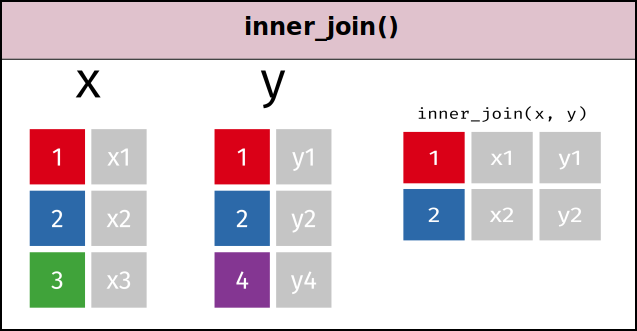

##### Left Join

```r
#- includes all observations in x, regardless of whether they match or not.
#- This is the most commonly used join because it ensures that you don’t lose observations from your primary table.
df_left_join <- left_join(x, y)
```

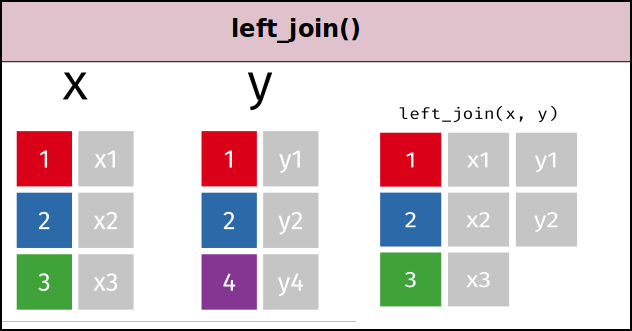

##### Right Joint

```r
#- includes all observations in y.
#- It’s equivalent to left_join(y, x), but the columns will be ordered differently.
df_right_join <- right_join(x, y)
```

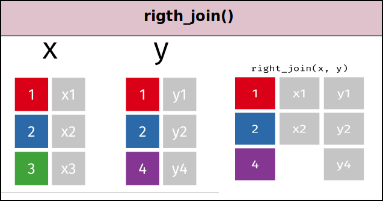

##### Full Joint

```r
#- full_join() includes all observations from x and y
df_full_join <- full_join(x, y)
```

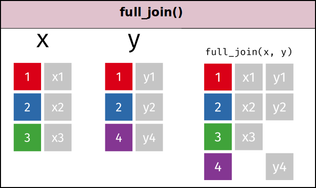

##### 2 precisiones sobre las mutating joins

Las (left, right and full) joins se llaman colectivamente como “outer joins”. Cuando una fila no tiene match en una outer join, las nuevas variables que se crean se llenan con NA’s.

Las mutating joins se usan principalmente para añadir columnas, **PERO** en el proceso pueden generarse nuevas filas: si un match no es único, se añadirán todas las combinaciones posibles (el producto cartesiano) de las matching observations. Veamos un ejemplo con una left_join:

```r
x <- tibble(id = 1:3, x = paste0("x", 1:3))

y <- tibble(id = c(1:4,2)[-3], y = paste0("y", c(1:5)[-3]))
```

##### left_join() en la que se crean nuevas filas

```r
df_left_join <- left_join(x, y)
```

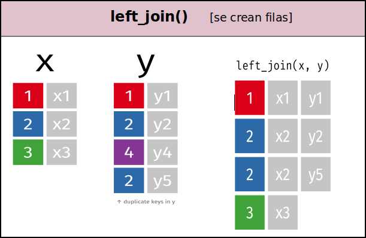

#### Importante ¿Cómo decir a las funciones la columnas (o columnas) que se usarán para hacer los matching?

Podemos(DEBEMOS) elegir las columnas (o variables) que nos servirán para unir los 2 df’s. Estas columnas que se usan para para hallar los matchings y que por tanto nos permiten fusionar los 2 df’s se llaman “keys”.

La opción de las funciones para seleccionar estas columnas “keys” es `by =`.

- si ponemos `left_join(df1, df2, by = "X1")` se hará una left_join siendo la variable “X1” la que hará de key. Si las variables key no se llamasen igual en los 2 df’s siempre podemos renombrarlas o hacer lo siguiente: `left_join(df1, df2, by = c("X1" = "D4")`
- También se pueden fusionar tablas usando dos keys; por ejemplo: `left_join(df1, df2, by = c("X1", "X2"))` . Si no se llamasen igual las variables en df1 y df2 haríamos `left_join(df1, df2, by = c("X1" = "D4", "X2" = "D7"))`

## Filtering joins

Filtering joins son similares a los anteriores (Mutating joins); o sea, hacen machting con las filas de la misma manera, **PERO afectan a las filas**, NO a las columnas. Hay filtering joins de 2 tipos:

- `semi_join(df1,df2)`: retorna las observaciones de df1 que tienen un match en df2. En cuanto a las columnas sólo retorna las columnas de df1
- `anti_join(df1,df2)`: retorna las observaciones de df1 que NO tienen un match en df2; osea, quita las observaciones con match. En cuanto a las columnas sólo retorna las columnas de df1

La semi_join se diferencia de la inner_join en que la inner_join solo retorna una fila de df1 por cada matching, mientras que **la semi_join NUNCA duplica filas de df1**

Las filtering joins son útiles para diagnosticar mismatches. Si quieres saber sobre los matches, haz una semi_join() or anti_join(). semi_join() and anti_join() NUNCA duplican filas; solo pueden quitar filas.

##### semi_join

```r
df_semi_join <-  semi_join(x, y, by = "id")
```

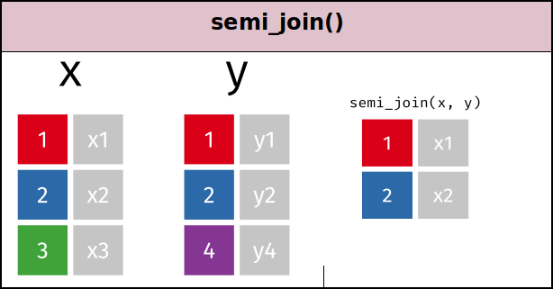

##### anti_join

```r
df_anti_join <-  anti_join(x, y, by = "id")
```

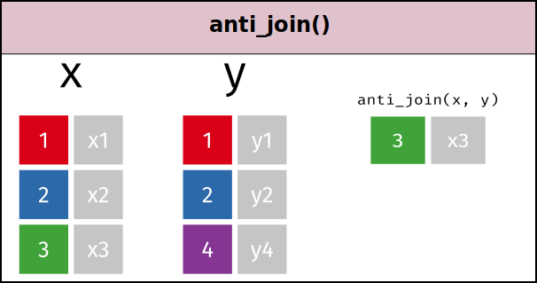

##### comparemos la semi_join con la inner_join

```r
df_inner <-  inner_join(x, y, by = "id")
df_semi_join <-  semi_join(x, y, by = "id")
```

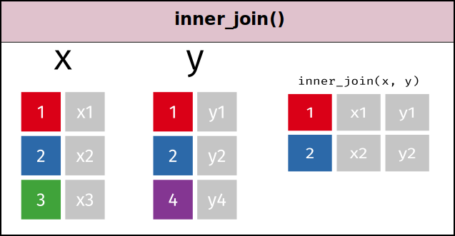

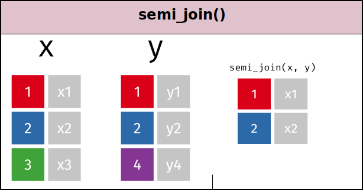

#### Importante ¿Cómo decir a las funciones la columna, o columnas, que se usarán para hacer los matching?

Al igual que con las mutating joins, en las filtering joins también podemos(DEBEMOS) elegir las columnas (o variables) que nos servirán para unir los 2 df’s. Estas columnas que se usan para para hallar los matchings y que por tanto que permiten fusionar los 2 df’s se llaman “keys”.

La opción de las funciones para seleccionar estas columnas “keys” es `by =`.

- si ponemos `semi_join(df1, df2, by = "X1")` se hará una semi_join siendo la variable “X1” la que hará de key. Si las variables key no se llamasen igual en los 2 df’s siempre podemos renombrarlas o hacer `semi_join(df1, df2, by = c("X1" = "D4")`
- si ponemos `semi_join(df1, df2,by = c("X1", "X2")` hará falta que una row de df1 tenga los valores tanto de X1 como de X2 iguales a los de esas mismas variables en df2. Si no se llamasen igual las variables en df1 y df2 haríamos `by = c("X1" = "D4", "X2" = "D7")`

## Set operations

Este tipo de joins es más estricta: **hace falta que los 2 df’s tengan las mismas variables (o columnas)**. Los 2 df’s pueden tener observaciones(filas) diferentes, PERO es necesario que tengan las mismas variables (o columnas).

Como los 2 df’s tienen las mismas columnas, entonces es como si se tratasen los dfs como conjuntos:

- `intersect(df1, df2)`: devuelve un df con las observaciones comunes en df1 y df2
- `union(df1, df2)`: devuelve la unión; o sea, las observaciones de df1 y de df2 (quitando las posibles filas duplicadas)
- `union_all(df1, df2)`: devuelve la unión (sin quitar los duplicados)
- `setdiff(df1, df2)`: devuelve las filas en df1 que no están en df2
- `setequal(df1,df2`: retorna TRUE si df y df2 tienen exactamente las mismas filas (da igual el orden en el que estén las filas)

```r
x <- tibble::tibble(v1 = c(1, 1, 2), v2 = c("a" , "b", "a"))
y <- tibble::tibble(v1 = c(1, 2),    v2 = c("a" , "b"))
```

##### intersección

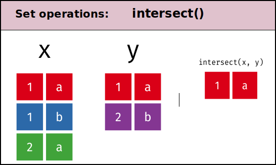

```r
intersect(x, y)
```

##### unión

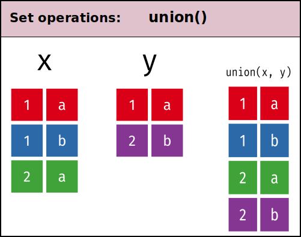

```r
union(x, y)
```

##### setdiff

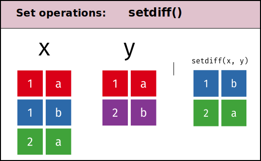

```r
setdiff(x, y)
```

Puedes probar tú mismo a cambiar el orden del los df’s en `setdiff()`:

```r
setdiff(y, x)
```

##### setqual

Sirve para determinar si 2 df’s son iguales (sin importar el orden en que estén las filas)

```r
setequal(x, y)
```

```
#> [1] FALSE
```

```r
setequal(union(x, y), union(y, x))
```

```
#> [1] TRUE
```

# Esperando a GODOT/ggplot2

Bueno, pues hemos visto “TODO” sobre manipulación de datos. El próximo tutorial va de visualización: hacia ggplot2

Aquí un pequeño avance:

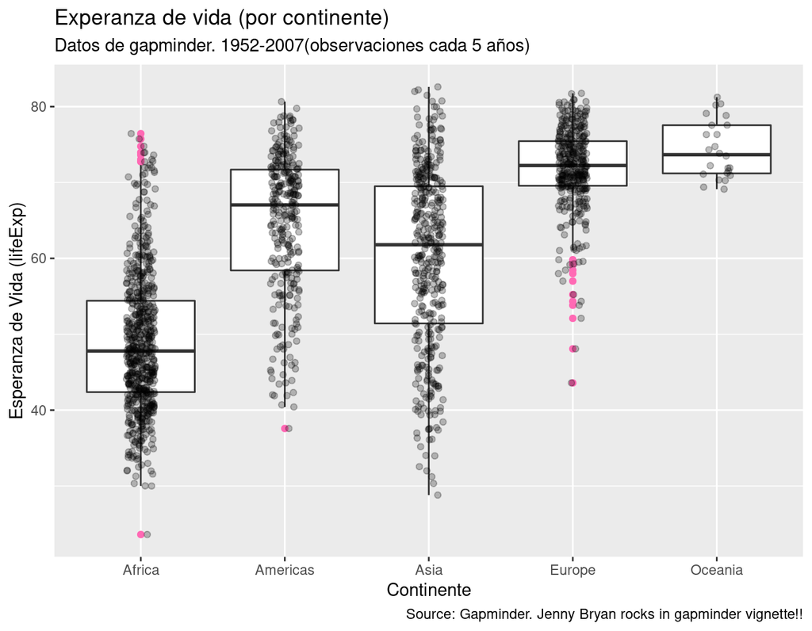

```r
library("ggplot2")
my_plot <- ggplot(gapminder, aes(x = continent, y = lifeExp)) +
  geom_boxplot(outlier.colour = "hotpink") +
  geom_jitter(position = position_jitter(width = 0.1, height = 0), alpha = 1/4) +
  labs(title = "Experanza de vida (por continente)",
       subtitle = "Datos de gapminder. 1952-2007(observaciones cada 5 años)",
       caption = "Source: Gapminder. Jenny Bryan rocks in gapminder vignette!!",
       x = "Continente", y = "Esperanza de Vida (lifeExp)")
```

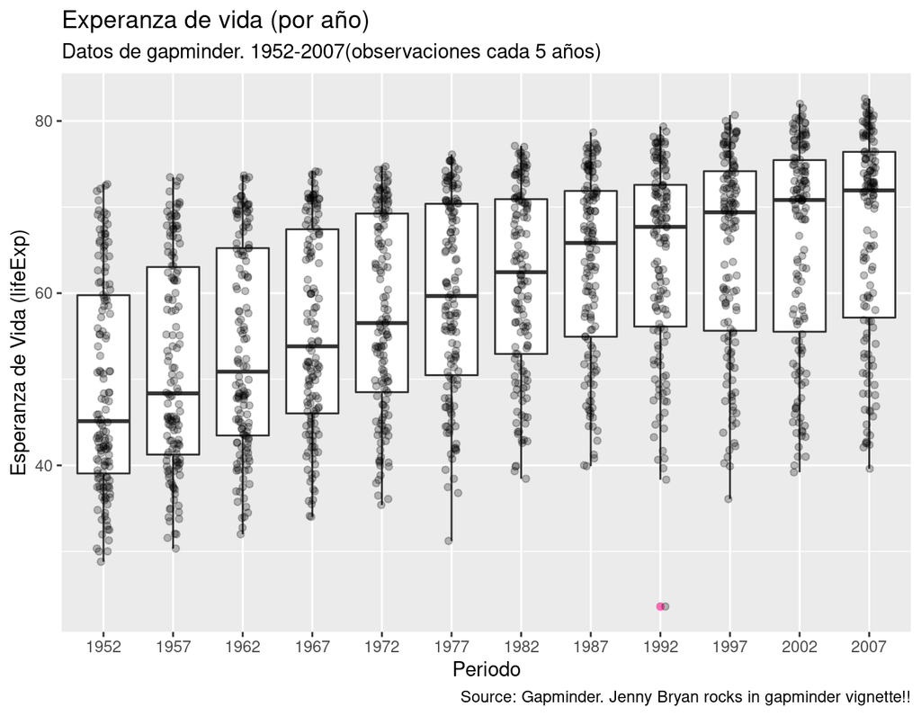

```r
gapminder2 <- gapminder %>% mutate(year = as.factor(year))

library("ggplot2")
my_plot <- ggplot(gapminder2, aes(x = year, y = lifeExp)) +
  geom_boxplot(outlier.colour = "hotpink") +
  geom_jitter(position = position_jitter(width = 0.1, height = 0), alpha = 1/4) +
  labs(title = "Experanza de vida (por año)",
       subtitle = "Datos de gapminder. 1952-2007(observaciones cada 5 años)",
       caption = "Source: Gapminder. Jenny Bryan rocks in gapminder vignette!!",
       x = "Periodo", y = "Esperanza de Vida (lifeExp)")
```

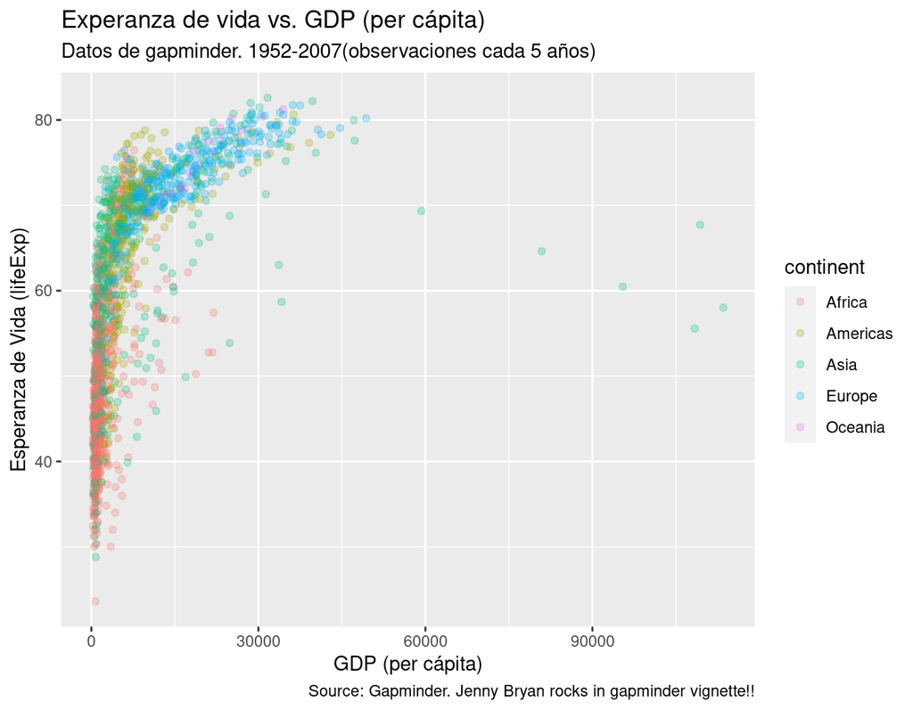

```r
library("ggplot2")
my_plot <- ggplot(gapminder, aes(x = gdpPercap, y = lifeExp, colour = continent)) +
  geom_jitter(position = position_jitter(width = 0.1, height = 0), alpha = 1/4) +
  labs(title = "Experanza de vida vs. GDP (per cápita)",
       subtitle = "Datos de gapminder. 1952-2007(observaciones cada 5 años)",
       caption = "Source: Gapminder. Jenny Bryan rocks in gapminder vignette!!",
       x = "GDP (per cápita)", y = "Esperanza de Vida (lifeExp)")
```

# Tidylog package

Una herramienta que os puede ser de utilidad para aprender el uso de `dplyr` es el paquete [`tidylog`](https://github.com/elbersb/tidylog). Este paquete nos da feedback instantáneo sobre qué hacemos cuando usamos las principales funciones de `dplyr` y `tidyr`. Veámoslo en acción:

```r
library("dplyr")
library("tidyr")
library("tidylog", warn.conflicts = FALSE)
filtered <- filter(mtcars, cyl == 4)
```

```
#> filter: removed 21 rows (66%), 11 rows remaining
```

```r
mutated <- mutate(mtcars, new_var = wt ** 2)
```

```
#> mutate: new variable 'new_var' (double) with 29 unique values and 0% NA
```

Si os fijáis, cada vez que ejecutas una función de `dplyr` nos devuelve un mensaje explicándonos que se ha hecho. Por ejemplo la linea de código `filtered <- filter(mtcars, cyl == 4)` ha creado un nuevo data.frame donde se han eliminado 21 filas del df original: `#> filter: removed 21 rows (66%), 11 rows remaining`.

La segunda linea de código `mutated <- mutate(mtcars, new_var = wt ** 2)` ha creado una nueva variable con `mutate()`: `#> mutate: new variable 'new_var' with 29 unique values and 0% NA`.

# Tidyverse vs. Base R

Todo lo que se puede hacer con dplyr, tidyr etc. ,también se puede hacer con Base-R pero de una manera mucho menos intuitiva.

El siguiente ejemplo esta sacado de [este post](https://www.r-bloggers.com/when-i-use-plyrdplyr/). Son dos trozos de código que hacen exactamente lo mismo:

Con el tidyverse:

```r
library(dplyr)
mtcars %>%
  group_by(cyl, am) %>%
  select(mpg, cyl, wt, am) %>%
  summarise(avgmpg = mean(mpg), avgwt = mean(wt)) %>%
  filter(avgmpg > 20)
```

Con la sintaxis de base R:

```r
filter(
  summarise(
    select(
      group_by(mtcars, cyl, am),
      mpg, cyl, wt, am),
    avgmpg = mean(mpg), avgwt = mean(wt)),
  avgmpg > 20)
```

O puesto en horizontal

```r
filter(summarise(select(group_by(mtcars, cyl, am),  mpg, cyl, wt, am),avgmpg = mean(mpg), avgwt = mean(wt)), avgmpg > 20)
```

##### Otros 2 ejemplos de comparación tidyverse versus Base-R:

```r
df %>% filter(country == "Spain") %>%  select(year, lifeExp)

df[df$country == "Spain", c("year", "lifeExp")]
```

Este último ejemplo lo introduzco porque quiero recordar [estas trasparencias](https://cerebralmastication.github.io/down_with_opp_dplyr.html#/) que explican que el paquete `dbplyr` traduce expresiones de dplyr a SQL. El código de las transparencias está [aquí](https://github.com/CerebralMastication/Presentations), y [aquí](https://db.rstudio.com/dplyr/) puedes aprender como hacer queries SQL a un database utilizando la sintaxis de dplyr.

```r
#- con tidyverse
df_cars %>%
  select(longname, cyl, hp) %>%
  mutate( shortname = word(longname, 1) ) %>%
  select( - longname)  ->
df_cars_limited
head( df_cars_limited )

#- con dplyr PERO sin %>%
head(
  select(
    mutate(
      select(df_cars, longname, cyl, hp) ,
      shortname = word(longname, 1)
      ),
    -longname
    )
)
```

# Bibliografía

- [Introducción a dplyr](http://stat545.com/block009_dplyr-intro.html). Jenny Bryan nos cuenta (en sus FANTASTICOS materiales para el curso STAT545) los rudimentos de dplyr. Buena parte de este tutorial se basa en el suyo.
- [dplyr functions for a single dataset](http://stat545.com/block010_dplyr-end-single-table.html). Otro material de Jenny del curso STAT545 sobre dplyr
- [dplyr CHEAT SHEET](https://www.rstudio.com/resources/cheatsheets/). FANTASTIQUÉRRIMA!!! Impresionante!!
- [Cápitulo de R4DS sobre “dplyr”](http://r4ds.had.co.nz/transform.html). De Hadley. Fantástico libro y fantástico capítulo sobre manejo de datos (dplyr).
- [A new data processing workflow for R: dplyr, magrittr, tidyr, ggplot2](http://zevross.com/blog/2015/01/13/a-new-data-processing-workflow-for-r-dplyr-magrittr-tidyr-ggplot2/). Post de un nuevo convencido de las bondades del tidyverse. Un ejemplo sencillo pero ilustrativo.
- [Wide & Long Data](https://stanford.edu/~ejdemyr/r-tutorials/wide-and-long/) Post que explica los beneficios de trabajar con datos en formato long (tidy).
- La biblia del tidy data. Vignette de tidyr package escrita por Hadley Wickham que explica con MUCHO detalle que son los tidy data.
- [Lesser known dplyr functions](https://statisticaloddsandends.wordpress.com/2019/08/30/lesser-known-dplyr-functions/). Un post fantástico sobre algunas funciones no tan conocidas de `dplyr`.
- [Viñetas oficiales de dplyr 1.0.0](https://dplyr.tidyverse.org/index.html). Están en la sección “Artículos”. Explican muy bien el funcionamiento de las nuevas funciones de dplyr 1.0.0
- Durante el proceso de anuncio oficial de dplyr 1.0.0 se publicaron una serie de posts oficiales del tidyverse, concretamente [aquí](https://www.tidyverse.org/blog/2020/06/dplyr-1-0-0/), [aquí](https://www.tidyverse.org/blog/2020/04/dplyr-1-0-0-and-vctrs/), [aquí](https://www.tidyverse.org/blog/2020/03/dplyr-1-0-0-select-rename-relocate/), [aquí](https://www.tidyverse.org/blog/2020/05/dplyr-1-0-0-last-minute-additions/) y [aquí](https://www.tidyverse.org/blog/2020/03/dplyr-1-0-0-summarise/).Están muy bien.
- Keith McNulty también me ayudo a entender dplyr 1.00: [aquí](https://towardsdatascience.com/what-you-need-to-know-about-the-new-dplyr-1-0-0-7eaaaf6d78ac) y [aquí](https://towardsdatascience.com/five-tidyverse-tricks-you-may-not-know-about-c5026d5a19da)
- Rebecca Barter también hizo un [muy buen post](http://www.rebeccabarter.com/blog/2020-07-09-across/).
- Quizás el tutorial más completo que he visto lo hizo el equipo de ThinkR: [aquí](https://thinkr.fr/hey-quoi-de-neuf-dplyr-le-point-sur-la-v1/). Está en francés.
[^1]: Hasta la aparición de tidyr 1.0.0, las funciones que se usaban eran `gather()` y `spread()`. En [esta conferencia](https://www.youtube.com/watch?v=vYwXMnC03I4&list=LLLm6k7PgDjVcFXJDbWg_OaQ), Hadley Wickham nos contó que uno de sus grandes errores durante el desarrollo del tidyverse fue la elección de los nombres de las funciones `gather()` y `spread()`. Finalmente podemos decir: bye bye `gather()` y `spread()`, wellcome `tidyr 1.0.0` and `pivot_longer()` and `pivot_wider()`.
[^2]: La última vez que miré la cheatsheet aún no estaba actualizada para recoger los cambios que aparecieron en dplyr 1.0.0, pero aún así os resultará de mucha utilidad
[^3]: Hasta mayo de 2020, esto es, hasta dplyr 1.0.0, esto se hacia con la función `select_if()`
[^4]: Hasta la aparición de dplyr 1.0.0 en mayo de 2020, se utilizaba la función `sumarise_all()`